## Assignment 3

#### Due Friday, September 29 11:59 PM CT

### Preliminaries

Code to read in data and source the *viridis.R* file assumes: (1) that you have the following directories and files, where COURSE is the path to your top course directory (it might be something like “~/Documents/stat240”); (2) that you have set the *hw03* directory to be your working directory; and (3) that you have installed both the **tidyverse** and **viridisLite** packages.

- Directories
  - COURSE/homework/
  - COURSE/homework/hw03/
  - COURSE/data/
  - COURSE/scripts/
- Files
  - COURSE/homework/hw03/hw03.Rmd
  - COURSE/data/madison-weather-official-1969-2022.csv
  - COURSE/data/exoplanets-clean-through-2022.csv
  - COURSE/scripts/viridis.R

#### Notes

- You will need to install the `viridisLite` package if you have not done so already.
- Code in the file `viridis.R` changes the default color scheme in `ggplot2` so that:
  - default colors are easier to perceive by people with a variety of color blindness conditions
  - when color is used to represent a continuous variable, perception of changes of shade are more even than in the default choice.
- Replace the text “YOUR NAME HERE” in the YAML section with your name.
- Edit this file, answer the questions, knit, and submit your solutions by uploading the resulting HTML file to the course Canvas site. Be sure to review your HTML and ensure that your solutions appear as you expect prior to submitting.
- Post questions using Discord, visit the Learning Center, or attend office hours if you have questions.

### Aims

- Refine and expand **ggplot2** skills for making plots, including:
  - changing axis scales
  - using color and size
  - making bar plots for categorical data
  - breaking plots over multiple facets
- Demonstrate skills from **dplyr** for wrangling and summarizing data

### Problems

The following R chunk reads in the default exoplanet data, selects some variables, and changes some variable names. *Note: This data set is not the same as what you used in discussion this week. It has already been reduced to a file with one unique exoplanet per row and variables have been selected and renamed.*

```r
## Read in the csv file
planets = read_csv("../../data/exoplanets-clean-through-2022.csv")
```

1. A small number of planets have both an estimated mass AND an estimated radius less than those of the Earth. What are the names of these planets, what method(s) were used to detect them, and in what year were they discovered?
- Create a data summary table with the star name, planet name, method, year, mass, and radius of the planets that have **both** an estimated mass < 1 Earth mass **and** an estimated radius < 1 Earth radius.
- Order the rows increasing by mass.
- Print the entire table.

```r
## Add your code here
small_planets = planets %>% select(-id) %>%
  filter(radius < 1 & mass < 1) %>% arrange(mass)
print(small_planets, n = Inf)
```

```
## # A tibble: 11 × 6
##    planet       star       method                         year radius  mass
##    <chr>        <chr>      <chr>                         <dbl>  <dbl> <dbl>
##  1 Kepler-138 b Kepler-138 Transit                        2014  0.64  0.07
##  2 TRAPPIST-1 h TRAPPIST-1 Transit                        2017  0.755 0.326
##  3 LHS 1678 b   LHS 1678   Transit                        2021  0.696 0.35
##  4 TRAPPIST-1 d TRAPPIST-1 Transit                        2016  0.788 0.388
##  5 L 98-59 b    L 98-59    Transit                        2019  0.85  0.4
##  6 KOI-55 b     KOI-55     Orbital Brightness Modulation  2011  0.759 0.44
##  7 GJ 367 b     GJ 367     Transit                        2021  0.718 0.546
##  8 HD 23472 d   HD 23472   Transit                        2022  0.75  0.55
##  9 KOI-55 c     KOI-55     Orbital Brightness Modulation  2011  0.867 0.655
## 10 TRAPPIST-1 e TRAPPIST-1 Transit                        2017  0.92  0.692
## 11 HD 23472 e   HD 23472   Transit                        2022  0.818 0.72
```

2. Using the exoplanet data table `planets`:
- filter so that you only use planets discovered by the radial velocity method;
- remove cases where either of the variables `year` or `mass` (or both) are missing;
- for this subset of exoplanets, create a table with a data summary with the number of planets discovered and the minimum mass of these planets by year
- print the first 10 rows and all columns of this data summary

Then, make a scatter plot of this data such that:

- the size of points are proportional to the number of planets discovered that year
- the y-axis is on the log10 scale *(hint: consider `scale_y_continuous()` or `scale_y_log10()`)*
- the axes have descriptive labels, and
- the plot contains an informative title.

Note, a scatter plot where the size of the points is proportional to a numerical variable is called a *bubble plot*.

In addition to creating the graphic, respond to the question below the R chunk.

```r
### Add your code here
radial_planets = planets %>%
  filter(method == "Radial Velocity") %>%
  drop_na(year, mass) %>%
  group_by(year) %>%
  summarise(num_planets = n(), min_mass = min(mass))
head(radial_planets, 10)
```

```
## # A tibble: 10 × 3
##     year num_planets min_mass
##    <dbl>       <int>    <dbl>
##  1  1998           1   723.
##  2  1999           2   232.
##  3  2000           5   210.
##  4  2001           2  1392.
##  5  2002           3  1072.
##  6  2003           7   534.
##  7  2004           4     7.99
##  8  2005           6     6.83
##  9  2006           1  2225.
## 10  2007           2  1116.
```

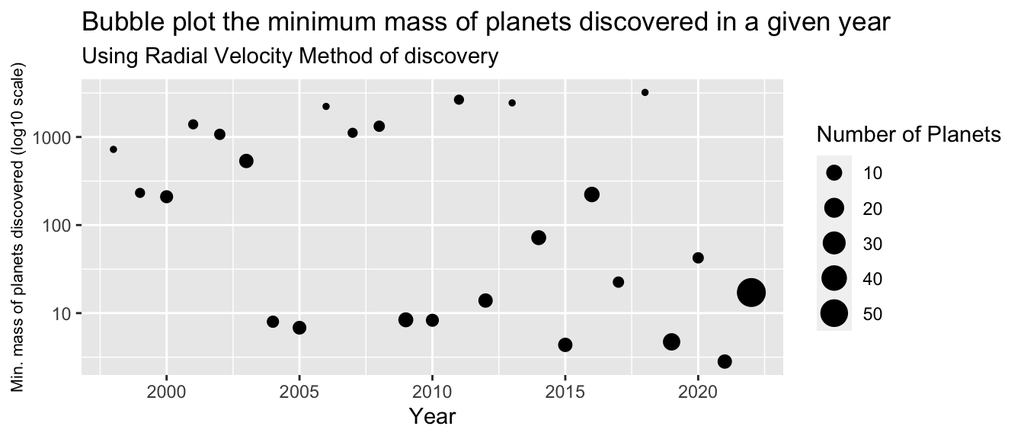

```r
ggplot(radial_planets, aes(x = year, y = min_mass, size=num_planets)) +
  geom_point() +
  scale_y_log10() +
  guides(size = guide_legend(title = "Number of Planets")) +
  xlab("Year") +
  ylab("Min. mass of planets discovered (log10 scale)") +
  ggtitle("Bubble plot the minimum mass of planets discovered in a given year", subtitle = "Using Radial Velocity Method of discovery") +
  theme(axis.title.y = element_text(size = 8))
```

**Describe the pattern between year and minimum mass of planet discovered using Radial Velocity.**

> While there’s no consistent pattern between the year and the minimum mass of planets discovered through Radial Velocity, a trend emerges upon closer inspection: planets with lower minimum masses have been increasingly discovered in more recent years. In contrast, the minimum masses detected during the 1990s and early 2000s were typically higher than those identified from the 2010s onwards.

> We also note that a higher number of planets are being discovered, as the size of the points in years 2010s to 2020s are much larger than that in the earlier years 1990s and 2000s.

> Therefore, we can conclude that there are a greater number of planets with the minimum mass being smaller being discovered as the years go by.
3. Using the `planets` data set created at the beginning of the assignment *(not the reduced data set from the previous problem)*, determine which methods have been used to discover fewer than 30 planets each. For use in the remaining exoplanet problems, create a subset of the data by:
- removing the planets discovered by those methods (with fewer than 30 exoplanet discoveries)
  - *(Hint: Consider creating a column which contains for each case the total number of times that the corresponding method appears in the data set and then using this information inside of `filter()`.)*

> Print a summary table with the methods used at least 30 times and the total number of exoplanets discovered by each, arranged from highest to lowest.

```r
### Add your code here
common_methods = planets %>% group_by(method) %>% summarise(num_per_method = n()) %>% filter(num_per_method >= 30) %>% arrange(desc(num_per_method))
common_methods
```

```
## # A tibble: 4 × 2
##   method          num_per_method
##   <chr>                    <int>
## 1 Transit                   3939
## 2 Radial Velocity           1024
## 3 Microlensing               152
## 4 Imaging                     62
```

- summarize *for each year*, the number of planets and the proportion of planets discovered by each method used 30 or more times. *(Note: filter to keep only methods that are used 30 or more times in the entire data set. Counts in a single year may be less.)*
  - proportions should sum to one within each year.
- arrange the rows by year in chronological order (earliest first)

This data summary should have one row for each year and method (if the method was used in that year) and columns with the names `year`, `method`, `n`, and `proportion`. *(Hint: you may find it helpful also to create a `total` column with the total number of exoplanets discovered each year repeated for each row to help calculate the proportion.)*

```r
### Add your code here
common_methods_names = common_methods %>% pull(method)

total_per_year = planets %>%
  filter(method %in% common_methods_names) %>%
  group_by(year) %>%
  summarise(total = n())

summary = planets %>%
  filter(method %in% common_methods_names) %>%
  group_by(year, method) %>%
  summarise(n = n()) %>%
  left_join(total_per_year) %>%
  mutate(proportion = n/total) %>%
  select(year, method, n, proportion)
```

Print the first 10 rows and all columns of this data summary.

```r
### Add your code here
head(summary,10)
```

```
## # A tibble: 10 × 4
## # Groups:   year [9]
##     year method              n proportion
##    <dbl> <chr>           <int>      <dbl>
##  1  1995 Radial Velocity     1     1
##  2  1996 Radial Velocity     6     1
##  3  1997 Radial Velocity     1     1
##  4  1998 Radial Velocity     6     1
##  5  1999 Radial Velocity    13     1
##  6  2000 Radial Velocity    16     1
##  7  2001 Radial Velocity    12     1
##  8  2002 Radial Velocity    28     0.966
##  9  2002 Transit             1     0.0345
## 10  2003 Radial Velocity    21     1
```

4. Using the data summary from the previous problem, create and display a bar plot with the year on the x axis and the proportion of discovered planets on the y axis. Let each year have a single bar that extends from a proportion of 0 to 1, with sections of each bar filled with a color by method Add appropriate axis labels and plot title.

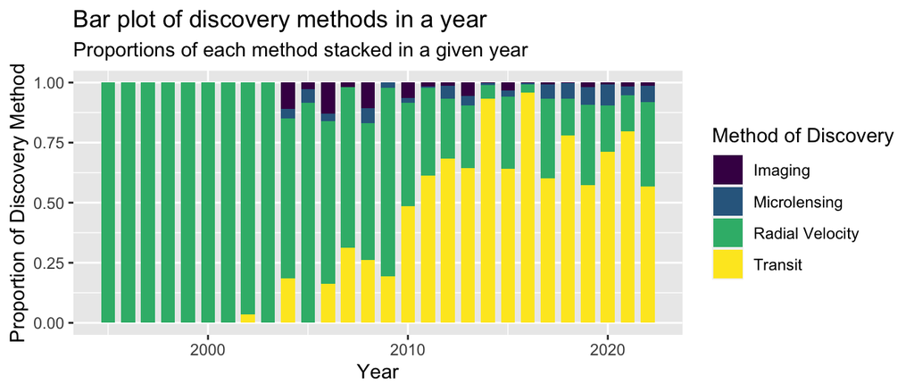

```r
### Add your code here
ggplot(summary, aes(x=year, y=proportion, fill = method)) +
  geom_col(position = position_stack(), width=0.7) +
  guides(fill = guide_legend(title = "Method of Discovery")) +
  xlab("Year") +
  ylab("Proportion of Discovery Method") +
  ggtitle("Bar plot of discovery methods in a year", subtitle = "Proportions of each method stacked in a given year")
```

Which method was most successful with the earliest discoveries of exoplanets, and which method has supplanted that method in relative popularity in recent years?

> The ‘Radial Velocity’ method was most successful in earliest discoveries of exoplanets, as depicted with the large proportion of green bars in the earlier years, but was supplanted by the ‘Transit’ method in recent years, as depicted by the yellow bars in recent years.
5. Begin with the data summary from the previous problem.
- filter to only include years from 2010 – 2022 (include the endpoints of the range), and
- remove the rows corresponding to the “Transit” or “Radial Velocity” methods.

Using this modified data set, create a plot which:

- displays the *counts* of exoplanets discovered by method with a bar graph with year on the x axis, different fill colors for each method, and the *counts* of the number of planets for each year and method on the y axis using the function `geom_col()`.
- does not stack the bars for each year, but rather display them next to each other in a clump by each year label. (*Note: The default is to stack bars. Use the argument `position = position_dodge2(preserve = "single")` inside of `geom_col()` to avoid stacking and to preserve the same bar width when the number of methods present changes by year.*)
- adjusts the x-axis so a tick mark and label appears for each year (i.e., 2010, 2011, …, 2022). **(Hint: consider `scale_x_continuous()`.)**
- uses appropriate axis labels and plot title.

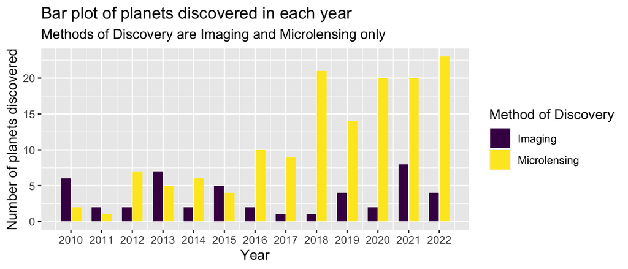

```r
## Add your code here
im_summary = summary %>% filter(year >= 2010 & year <= 2022 & method != 'Transit' & method != 'Radial Velocity')

ggplot(im_summary, aes(x=year, y=n, fill = method)) +
  geom_col(position = position_dodge2(preserve = "single"), width=0.7) +
  guides(fill = guide_legend(title = "Method of Discovery")) +
  scale_x_continuous(breaks = 2010:2022) +
  xlab("Year") +
  ylab("Number of planets discovered") +
  ggtitle("Bar plot of planets discovered in each year", subtitle = "Methods of Discovery are Imaging and Microlensing only")
```

6. Use the official Madison weather data. Find:
- **6a**. The dates with the five highest recorded maximum temperatures (there could be more than five dates due to ties)

```r
## Add your code here
top_five_temps = official %>%
  distinct(tmax) %>%
  arrange(desc(tmax)) %>%
  head(5) %>%
  pull(tmax)

top_temps_dates = official %>%
  arrange(desc(tmax)) %>%
  filter(tmax %in% top_five_temps) %>%
  select(date, tmax)

top_temps_dates
```

```
## # A tibble: 25 × 2
##    date        tmax
##    <date>     <dbl>
##  1 1936-07-14   107
##  2 1936-07-13   106
##  3 1901-07-21   104
##  4 1936-07-12   104
##  5 1976-07-10   104
##  6 2012-07-05   104
##  7 1936-07-07   102
##  8 1940-07-24   102
##  9 1977-07-14   102
## 10 1988-08-16   102
## # ℹ 15 more rows
```

- **6b**. The proportion of all days by month with positive precipitation.

```r
## Add your code here
pos_prcp = official %>%
  mutate(month = month(date, label = TRUE)) %>%
  group_by(month) %>%
  summarise(total_days = n(),
            positive_prcp_days = sum(prcp > 0, na.rm = TRUE),
            proportion = positive_prcp_days / total_days) %>%
  select(month, proportion)
pos_prcp
```

```
## # A tibble: 12 × 2
##    month proportion
##    <ord>      <dbl>
##  1 Jan        0.305
##  2 Feb        0.285
##  3 Mar        0.318
##  4 Apr        0.363
##  5 May        0.377
##  6 Jun        0.359
##  7 Jul        0.301
##  8 Aug        0.293
##  9 Sep        0.306
## 10 Oct        0.283
## 11 Nov        0.292
## 12 Dec        0.301
```

- **6c**. The average temperature (mean of `tavg`) by month for the years from 1991-2020. Consider these values to be the current *normal mean temperatures*. Then, find the average temperature by month in 2022. In how many months was the average temperature in 2022 higher than the normal mean temperature?

```r
## Add your code here
avg_temps = official %>%
  mutate(year = year(date), month = month(date, label = TRUE)) %>%
  filter(year >= 1991 & year <= 2020) %>%
  group_by(month) %>%
  summarise(mean_temp = mean(tavg))

twentytwo_avg_temps = official %>%
  mutate(year = year(date), month = month(date, label = TRUE)) %>%
  filter(year == 2022) %>%
  group_by(month) %>%
  summarise(twentytwo_temps = mean(tavg))

left_join(avg_temps,twentytwo_avg_temps)
```

```
## # A tibble: 12 × 3
##    month mean_temp twentytwo_temps
##    <ord>     <dbl>           <dbl>
##  1 Jan        19.5            14.4
##  2 Feb        23.2            21.4
##  3 Mar        34.5            34.4
##  4 Apr        46.5            43.4
##  5 May        58.2            62.1
##  6 Jun        68.1            69.0
##  7 Jul        72.0            72.7
##  8 Aug        69.8            70.3
##  9 Sep        62.1            63.1
## 10 Oct        49.8            50.1
## 11 Nov        36.9            38.6
## 12 Dec        25.3            24.5
```

```r
## Add your code here
ten_highest_avg = official %>%
  mutate(year = year(date)) %>%
  filter(year >= 1869) %>%
  group_by(year) %>%
  summarise(year_avg = max(tavg)) %>%
  arrange(desc(year_avg)) %>%
  head(10)

ten_highest_avg
```

[output not shown]

```r
mayjun_prcp = official %>%
  mutate(year = year(date), month = month(date, label = TRUE)) %>%
  filter(year >= 1869 & year <= 2022 & (month == 'May' | month == 'Jun')) %>%
  group_by(year, month) %>%
  summarise(total_prcp = sum(prcp))

mayjun_prcp_ranked = mayjun_prcp %>%
  arrange(month, total_prcp, year) %>%
  group_by(month) %>%
  mutate(rank = row_number())

# Get the top 25 driest Mays:
driest_mays = mayjun_prcp_ranked %>%
  filter(month == "May") %>%
  select(rank, everything()) %>%
  head(25)

driest_junes = mayjun_prcp_ranked %>%
  filter(month == "Jun") %>%
  select(rank, everything()) %>%
  head(25)

print(driest_mays, n=25)
```

```
## # A tibble: 25 × 4
## # Groups:   month [1]
##     rank  year month total_prcp
##    <int> <dbl> <ord>      <dbl>
##  1     1  1925 May         0.38
##  2     2  1897 May         0.51
##  3     3  1981 May         0.64
##  4     4  1936 May         0.79
##  5     5  1934 May         0.82
##  6     6  1988 May         0.92
##  7     7  1971 May         0.98
##  8     8  1877 May         1.02
##  9     9  1953 May         1.02
## 10    10  1870 May         1.09
## 11    11  1992 May         1.12
## 12    12  1961 May         1.17
## 13    13  1929 May         1.31
## 14    14  1994 May         1.33
## 15    15  2007 May         1.4
## 16    16  1891 May         1.42
## 17    17  1924 May         1.46
## 18    18  1937 May         1.49
## 19    19  1939 May         1.64
## 20    20  1885 May         1.68
## 21    21  1989 May         1.72
## 22    22  1931 May         1.74
## 23    23  1963 May         1.82
## 24    24  1965 May         1.86
## 25    25  1900 May         1.86
```

```r
print(driest_junes, n=25)
```

```
## # A tibble: 25 × 4
## # Groups:   month [1]
##     rank  year month total_prcp
##    <int> <dbl> <ord>      <dbl>
##  1     1  2012 Jun         0.31
##  2     2  1895 Jun         0.59
##  3     3  1973 Jun         0.81
##  4     4  1886 Jun         1.08
##  5     5  1912 Jun         1.13
##  6     6  1987 Jun         1.17
##  7     7  1995 Jun         1.22
##  8     8  1910 Jun         1.31
##  9     9  1976 Jun         1.38
## 10    10  1903 Jun         1.39
## 11    11  1887 Jun         1.48
## 12    12  1992 Jun         1.53
## 13    13  1933 Jun         1.64
## 14    14  2005 Jun         1.65
## 15    15  1972 Jun         1.65
## 16    16  1989 Jun         1.67
## 17    17  1915 Jun         1.75
## 18    18  1908 Jun         1.8
## 19    19  1961 Jun         1.84
## 20    20  1918 Jun         1.84
## 21    21  1983 Jun         1.85
## 22    22  1870 Jun         1.92
## 23    23  1889 Jun         2
## 24    24  1988 Jun         2.06
## 25    25  1960 Jun         2.09
```

> Write your answers here Answer: May 2023 would be ranked the 7th most driest May and Jun 2023 would be ranked the 6th most driest Jun
8. Return to the monthly total precipitation table for the months of May and June from 1869–2022. Create a new summary table by adding these totals for May and June within each year.
- This summary table should have a column for `year` and a column for the combined total precipitation in May and June.
- Make a plot which shows the combined total precipitation in May and June in Madison from 1869–2022 versus the year. Add a smooth trend curve to the plot. Add a red dashed horizontal line at the combined total precipitation in May and June for 2023. Include meaningful axis labels and a title for the plot.
- Comment on how the combined precipitation in these two months in 2023 compares to the historical weather record.

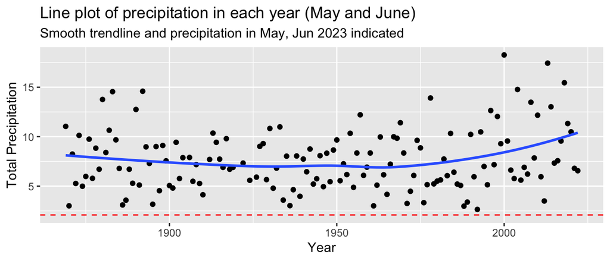

```r
combined = mayjun_prcp %>%
  group_by(year) %>%
  summarise(total_prcp = sum(total_prcp)) %>%
  drop_na()

ggplot(combined, aes(x=year, y=total_prcp)) +
  geom_point() +
  geom_hline(yintercept = (0.95+1.14), linetype = "dashed", color = "red") +
  geom_smooth(se = FALSE) +
  xlab("Year") +
  ylab("Total Precipitation") +
  ggtitle("Line plot of precipitation in each year (May and June)", subtitle = "Smooth trendline and precipitation in May, Jun 2023 indicated")
```

> The combined precipitation in these two months in 2023 is much lower than the historical weather record, lower than the trend line and any other year in historical data.